# BOGage planner: Informe del día 8/11/2024

Realizado el 2024-10-30

# a) Resumen de Parámetros de Entrada

En este apartado se mostrará el resumen de los parámetros de entrada introducidos.

## Parámetros de Pasajeros

Tabla de Parámetros de Pasajeros

| Parámetro | Valor |
| --- | --- |
| Pasajeros O/D | 60 % |
| Load Factor | 100 % |
| Equipajes/pasajero (doméstico) | 0.23 equipajes/pax |
| Equipajes/pasajero (internacional) | 0.72 equipajes/pax |
| Equipajes/pasajero (transferencias) | 0.4 equipajes/pax |

## Parámetros de los Equipos de Inspección

Tabla de Parámetros de los Equipos de Inspección

| Parámetro | Valor |
| --- | --- |
| Equipajes aprobados en nivel 1 | 80 % |
| Equipajes aprobados en nivel 2 | 17 % |
| Equipajes rechazados en nivel 1 | 2 % |
| Equipajes No Pic | 1 % |

## Parámetros de los Operadores de N2 y N3

Tabla de Parámetros de Operadores

| Parámetro | Valor |
| --- | --- |
| Capacidad de un operador de nivel 2 | 120 equipajes/hora |
| Capacidad de un operador de nivel 3 | 24 equipajes/hora |

## Parámetros Operativos

Tabla de Parámetros Operativos

| Parámetro | Valor |
| --- | --- |
| Recirculación de equipajes en el sorter | 8 % |
| Equipajes no leídos por ATR | 2 % |
| Equipajes lost-tracking previo a EDS | 1 % |
| Equipajes lost-tracking tras EDS | 1 % |

# b) Resultados

## Entrada de Equipajes al Sistema

### Tabla de Máxima Demanda

En esta tabla se mostrará la máxima demanda total y por línea de las diferentes áreas de facturación y líneas de transferencias.

Tabla de Entradas de Equipajes

| Línea de Entrada | Máxima demanda (equipajes/hora) |
| --- | --- |
| Total | 2050 |
| TR07 | 247 |
| TR08 | 141 |
| TR09 | 143 |
| TR10 | 490 |
| TR04 | 124 |
| TR03 | 124 |
| TR02 | 123 |
| TR01 | 122 |
| TX01 | 274 |
| TX02 | 317 |
| TX03 | 334 |
| TX04 | 312 |

### Resultados Gráficos

A continuación, se muestran las gráficas de demanda total y por línea de entrada de equipajes al sistema.

#### Entrada total de equipajes

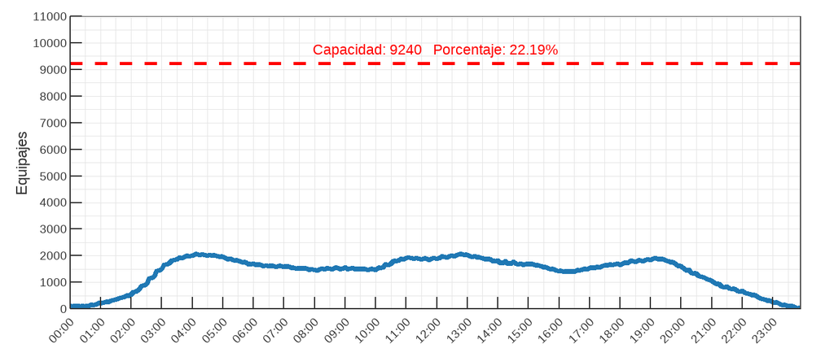

#### Línea TR07

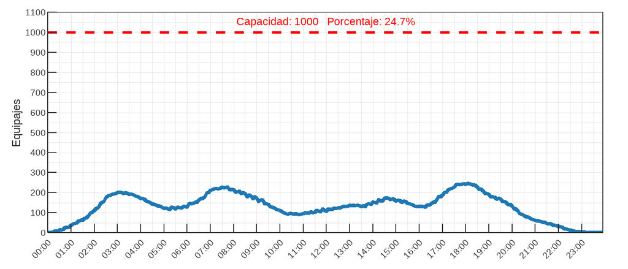

#### Línea TR08

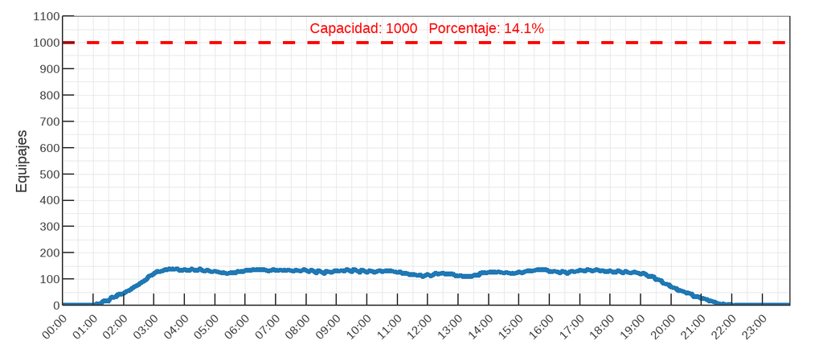

#### Línea TR09

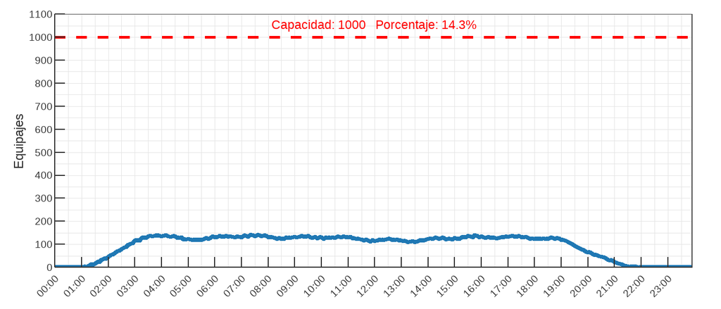

#### Línea TR10

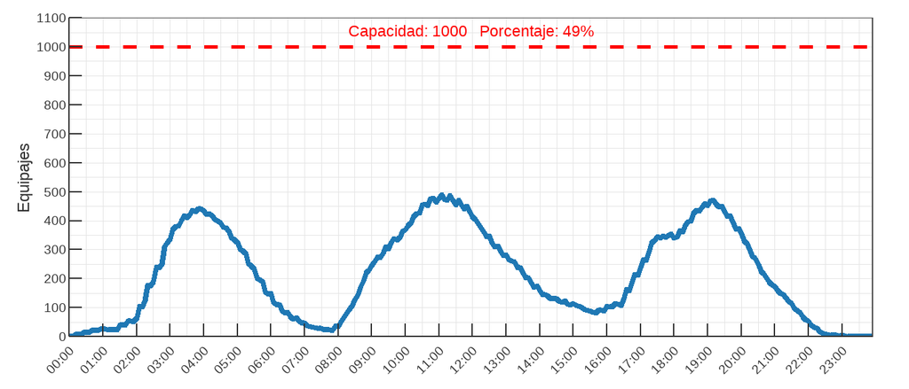

#### Línea TR04

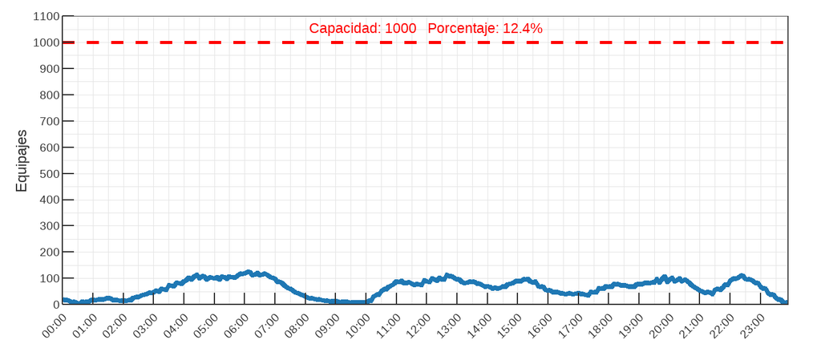

#### Línea TR03

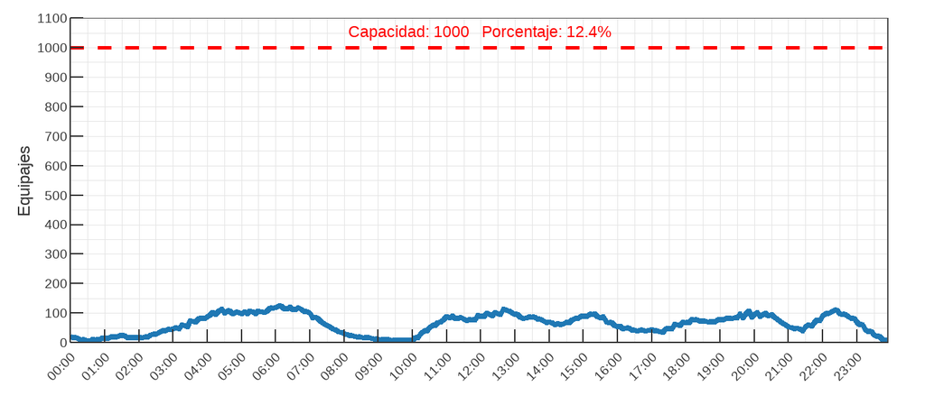

#### Línea TR02

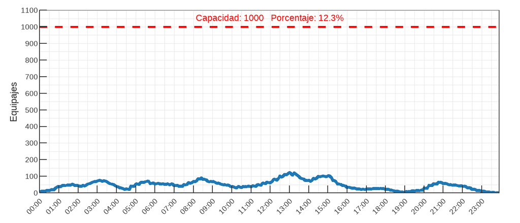

#### Línea TR01

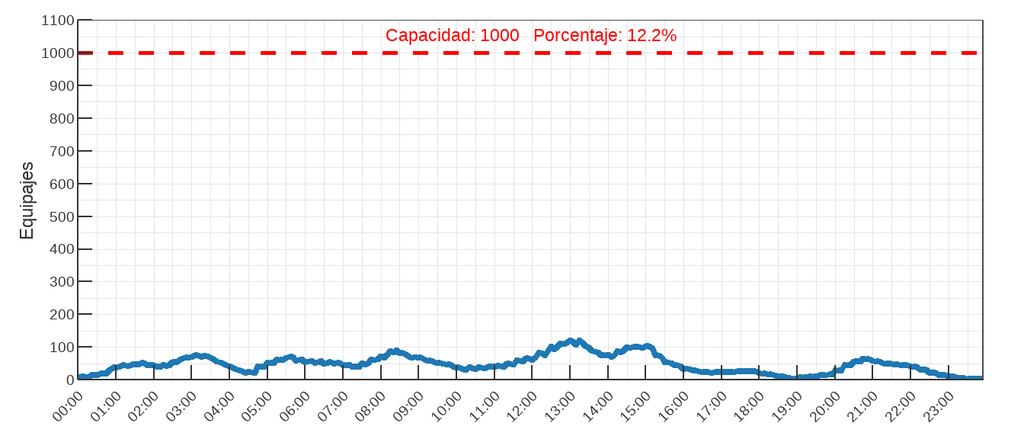

#### Línea TX01

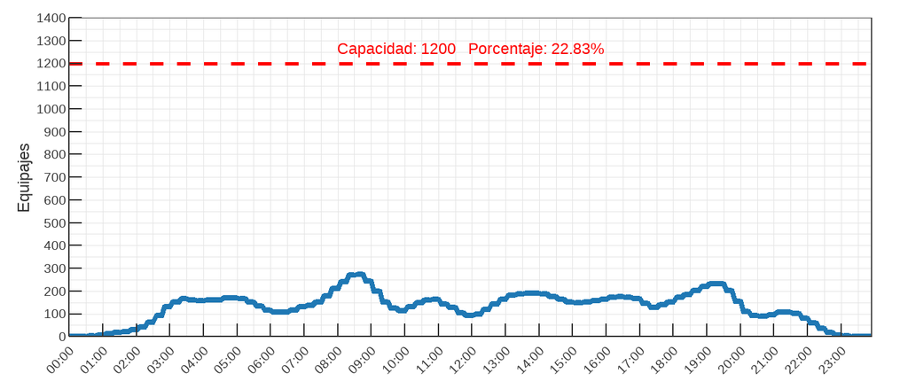

#### Línea TX02

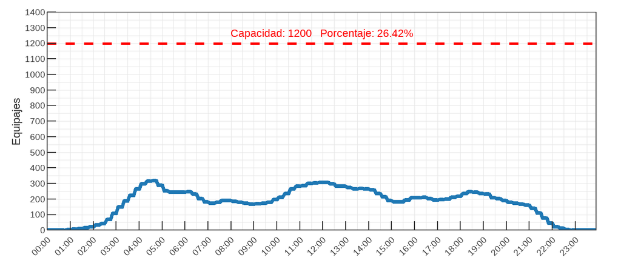

#### Línea TX03

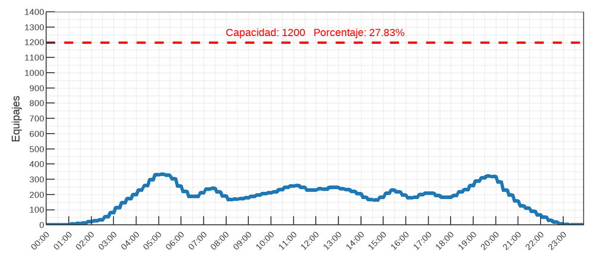

#### Línea TX04

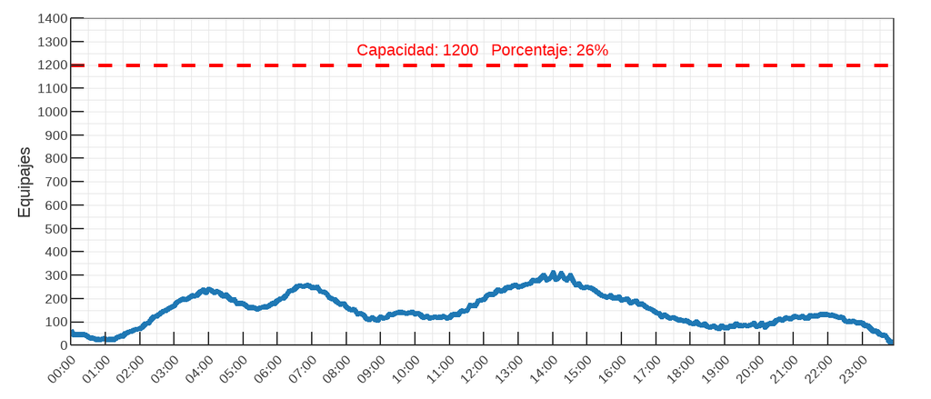

## Sorter

### Tabla de Máxima Demanda

En esta tabla se mostrará la máxima demanda en cada uno de los sorters.

Tabla de Sorter

| Sorter | Máxima demanda (equipajes/hora) |
| --- | --- |
| Total | 2214 |
| MS01 | 1020 |
| MS02 | 1251 |

### Resultados Gráficos

A continuación, se muestran las gráficas de demanda en los sorters.

#### Sorter MS01

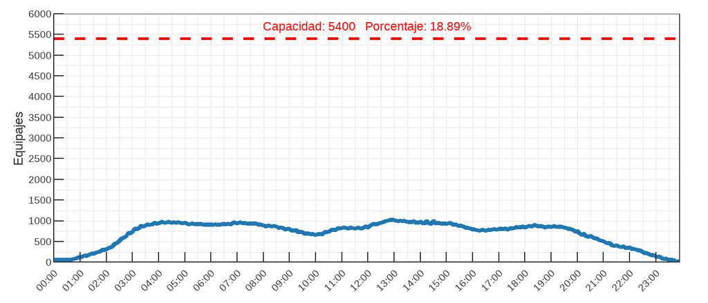

#### Sorter MS02

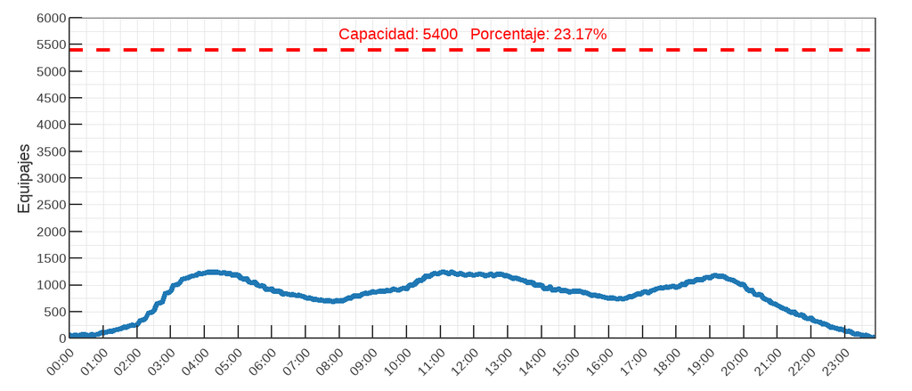

## Líneas EDS

### Tabla de Máxima Demanda

En esta tabla se mostrará la máxima demanda total y por línea de las líneas de EDS.

Tabla de Líneas EDS

| Línea de Inspección | Máxima demanda (equipajes/hora) |
| --- | --- |
| Total | 2050 |
| 1L1 | 201 |
| 1L2 | 202 |
| 1L3 | 202 |
| 1L4 | 478 |
| 1L5 | 344 |
| 1L6 | 407 |
| 1L7 | 406 |

### Resultados Gráficos

A continuación, se muestran las gráficas de demanda total y por línea en las líneas de EDS. Adicionalmente, se incluye la gráfica de necesidad de operadores de nivel 2.

#### Demanda Total

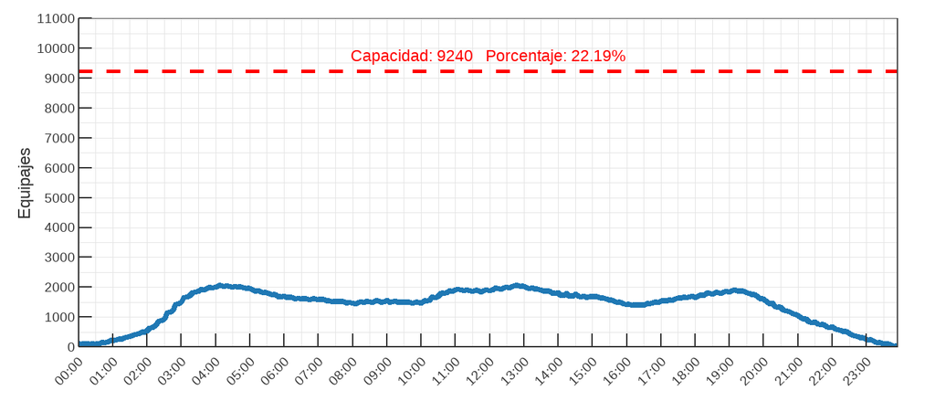

#### Operadores de Nivel 2 necesarios

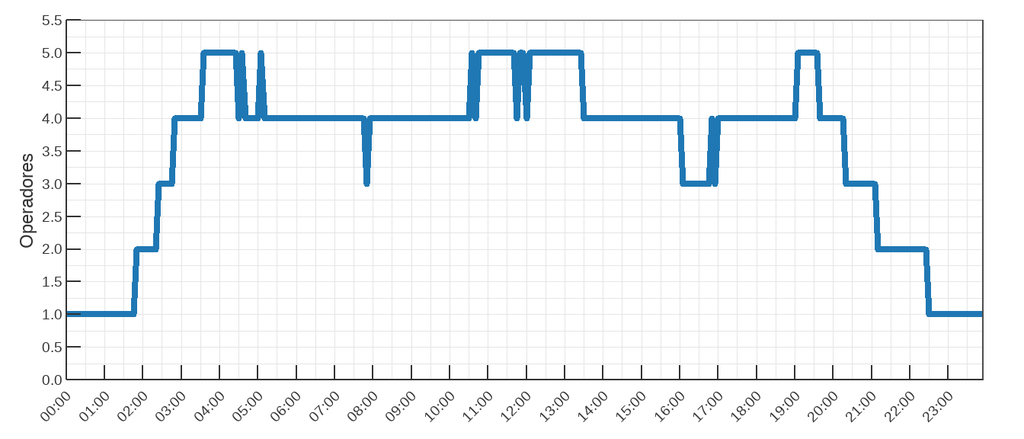

#### Línea 1L1

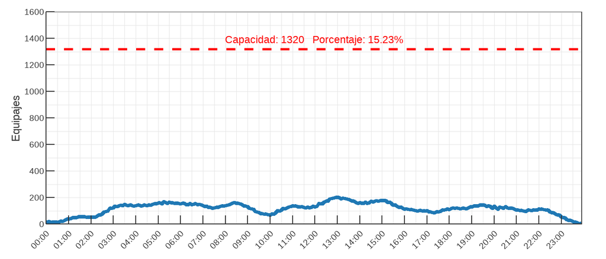

#### Línea 1L2

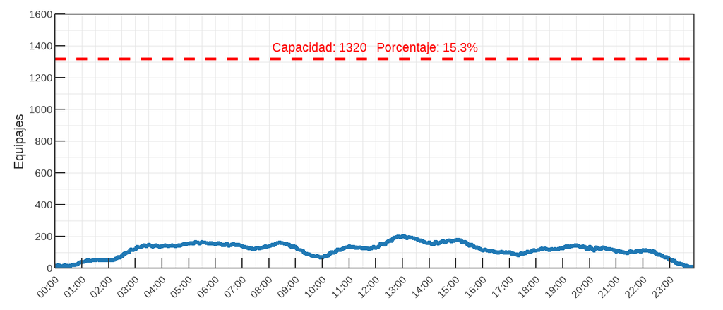

#### Línea 1L3

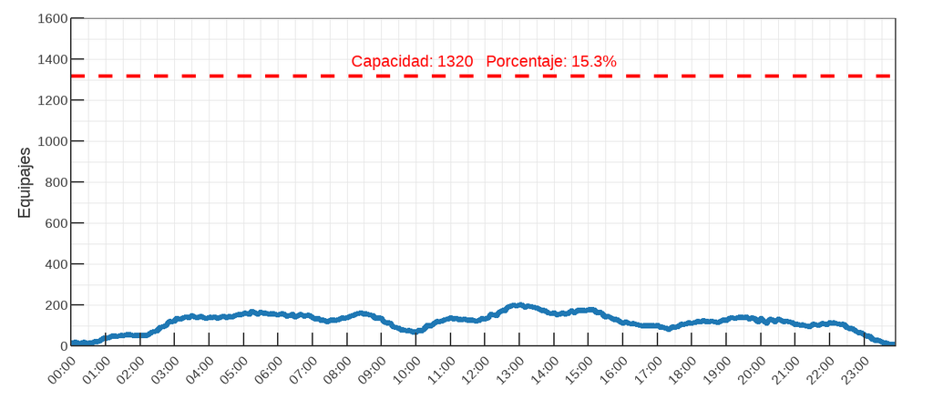

#### Línea 1L4

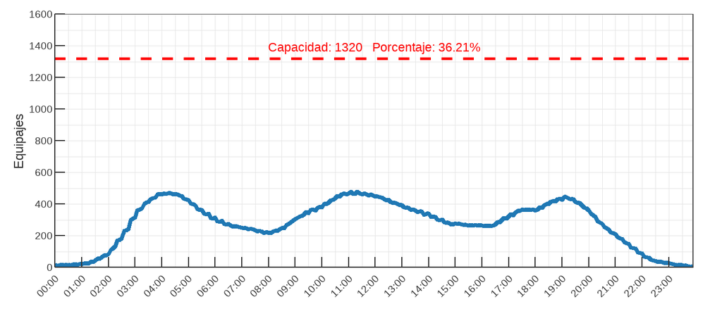

#### Línea 1L5

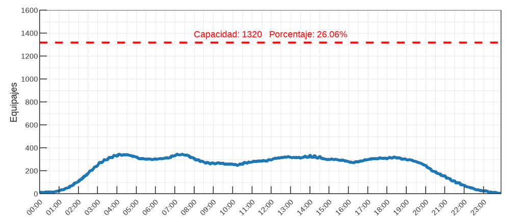

#### Línea 1L6

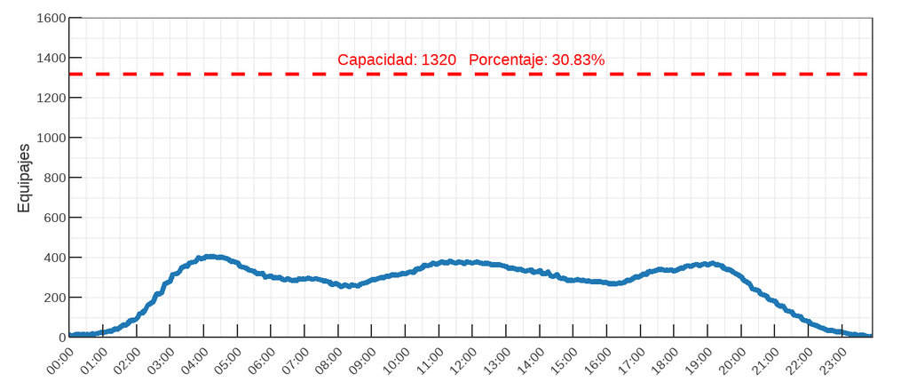

#### Línea 1L7

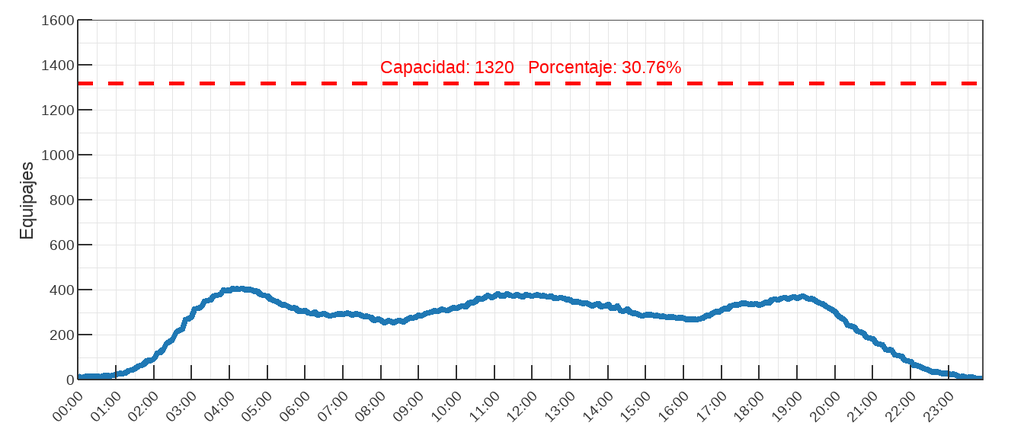

## Nivel 3

### Tabla de Máxima Demanda

En esta tabla se mostrará la máxima demanda y el máximo número de operadores necesarios en nivel 3.

Tabla de Nivel 3

| Nivel 3 | Máxima demanda (equipajes/hora) | Máximo número de operadores (operadores/hora) |
| --- | --- | --- |
| L3 | 88 | 5 |

### Resultados Gráficos

A continuación, se muestran las gráficas de demanda y de número de operadores necesarios en nivel 3.

#### Demanda de equipajes

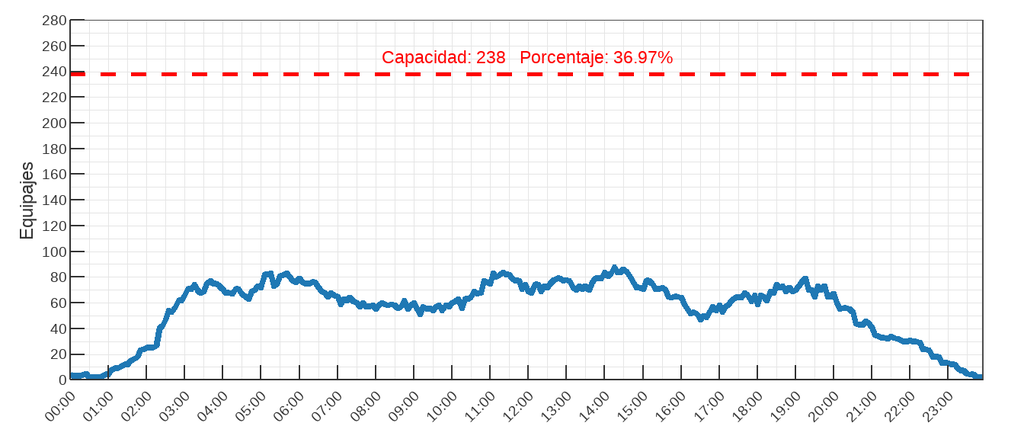

#### Operadores de Nivel 3 necesarios

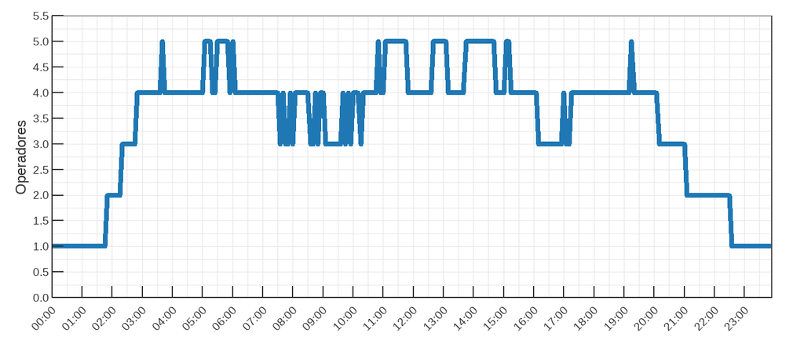

## Estación de Codificación Manual

### Tabla de Máxima Demanda

En esta tabla se mostrará la máxima demanda por estación de codificación manual.

Tabla de Estación de Codificación Manual (MES)

| Estación de Codificación Manual | Máxima demanda (equipajes/hora) |
| --- | --- |
| ME1 | 21 |
| ME2 | 20 |
| ME3 | 19 |
| ME4 | 29 |

### Resultados Gráficos

A continuación, se muestran las gráficas de demanda en cada estación de codificación manual.

#### Estación ME1

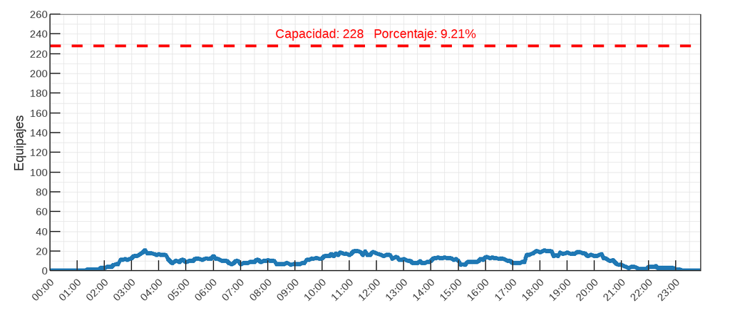

#### Estación ME2

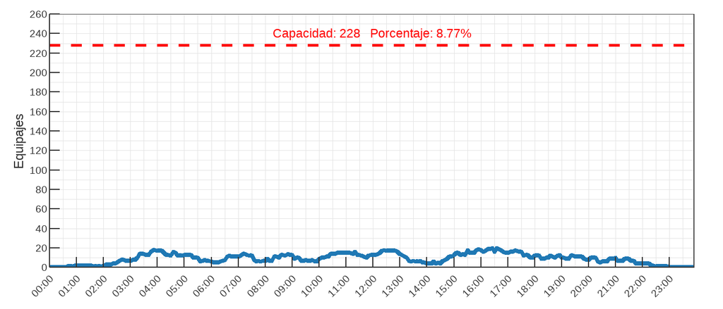

#### Estación ME3

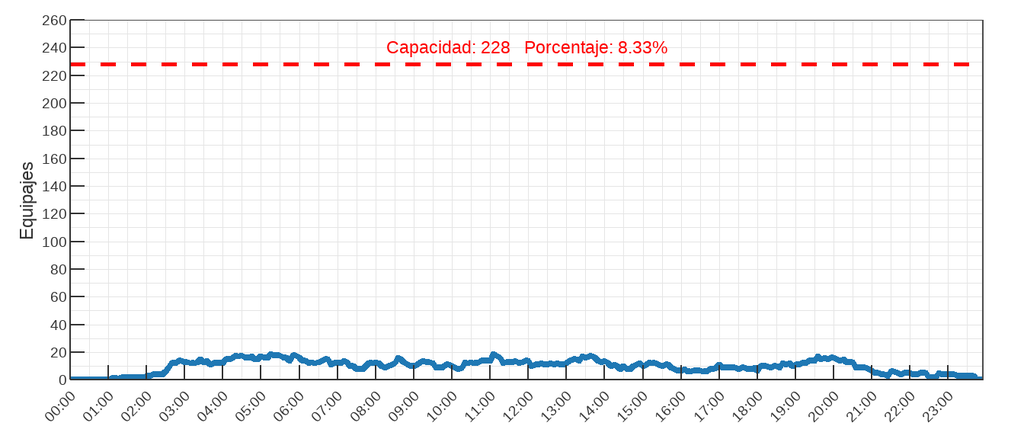

#### Estación ME4

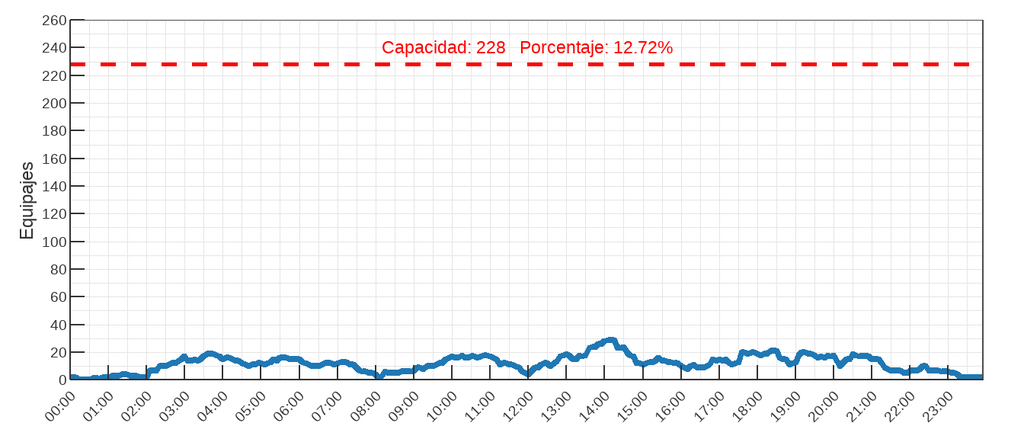

## Carruseles de make-up

### Tabla de Máxima Demanda

En esta tabla se mostrará la máxima demanda por línea de acceso a cada carrusel de make-up. Cabe aclarar que el MC04 es considerado como EBS manual y no se incluye en este apartado.

Tabla de Carruseles de Make-up

| Entrada a Make-Up | Máxima demanda (equipajes/hora) |
| --- | --- |
| MU01-1xx | 247 |
| MU01-2xx | 149 |
| MU02-1xx | 209 |
| MU02-2xx | 210 |
| MU03-1xx | 75 |
| MU03-2xx | 75 |
| MU05-1xx | 82 |
| MU05-2xx | 267 |
| MU06-1xx | 79 |
| MU06-2xx | 278 |
| MU07-1xx | 57 |
| MU07-2xx | 212 |
| MU08-1xx | 189 |
| MU08-2xx | 183 |
| MU09-1xx | 209 |
| MU09-2xx | 199 |
| MU10-1xx | 167 |
| MU10-2xx | 184 |
| MU11-1xx | 231 |
| MU11-2xx | 110 |

### Resultados Gráficos

A continuación, se muestran las gráficas de demanda en cada una de las líneas de acceso a los carruseles de make-up.

#### Carrusel MC01

##### Línea MU01-1xx

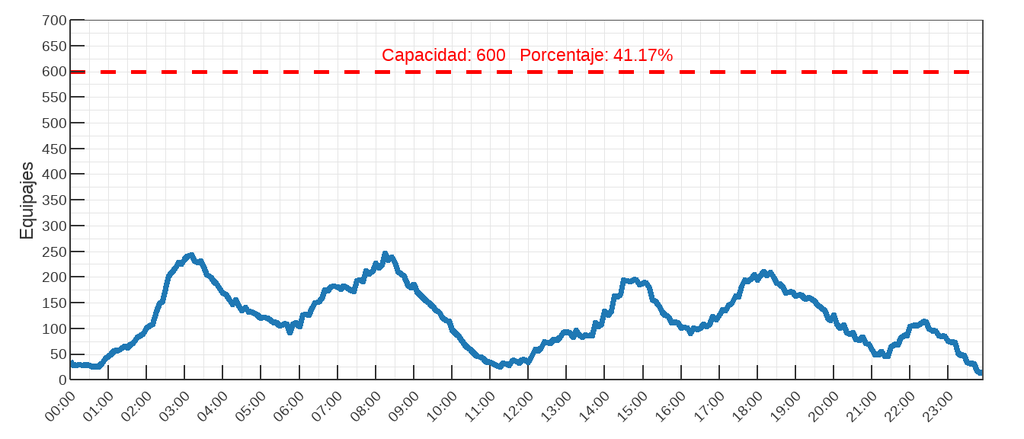

##### Línea MU01-2xx

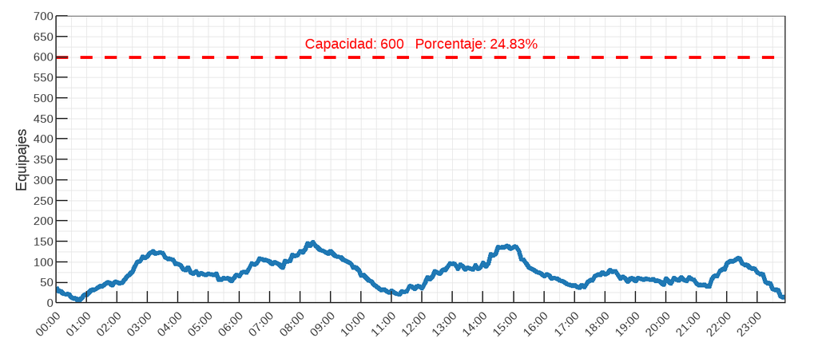

#### Carrusel MC02

##### Línea MU02-1xx

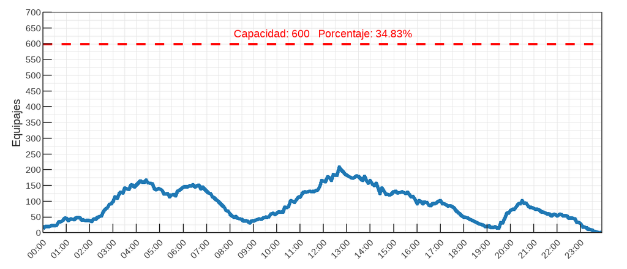

##### Línea MU02-2xx

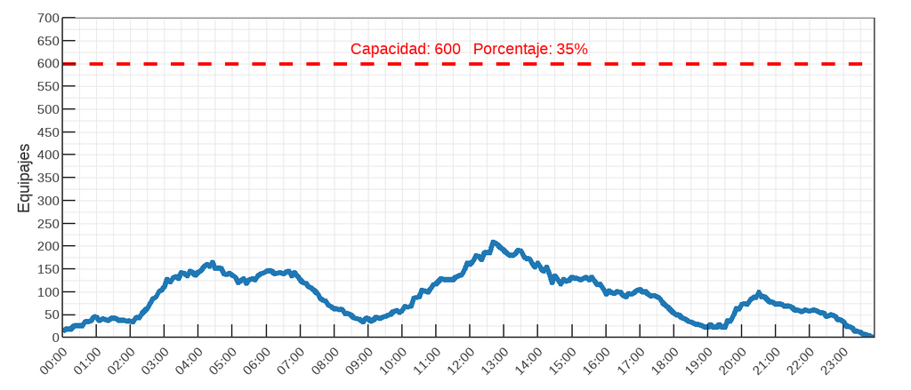

#### Carrusel MC03

##### Línea MU03-1xx

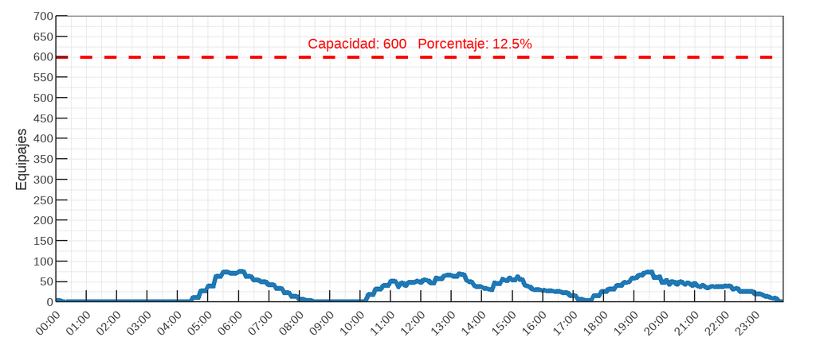

##### Línea MU03-2xx

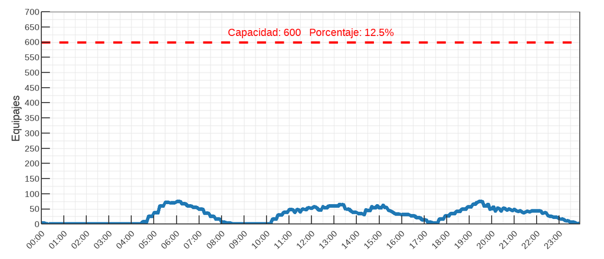

#### Carrusel MC05

##### Línea MU05-1xx

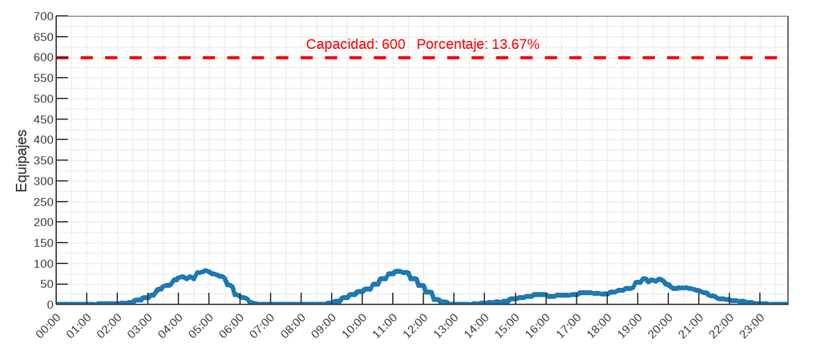

##### Línea MU05-2xx

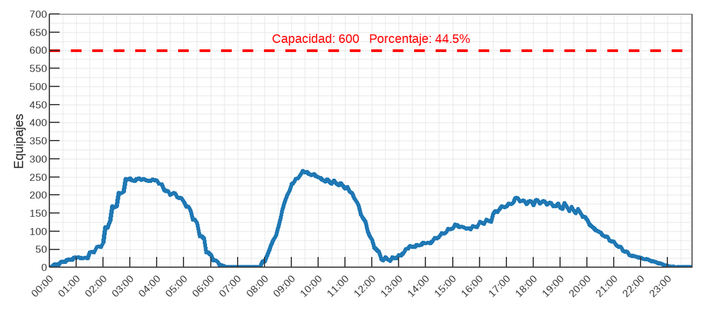

#### Carrusel MC06

##### Línea MU06-1xx

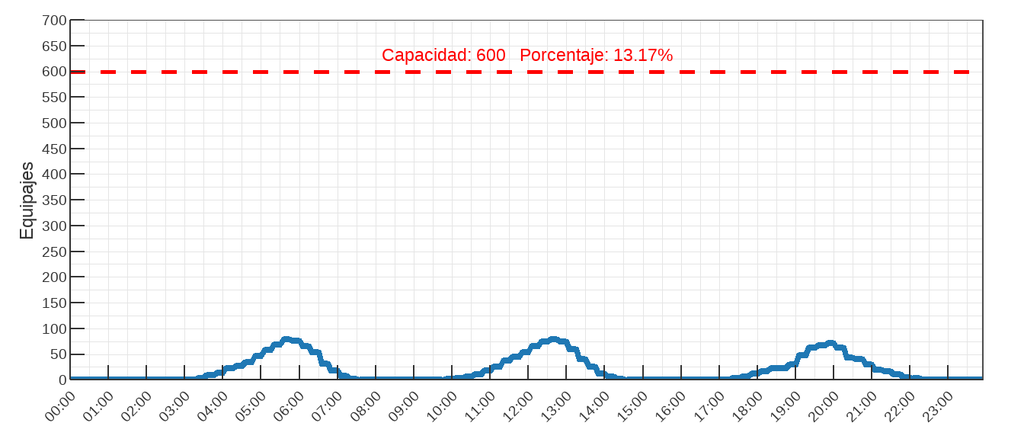

##### Línea MU06-2xx

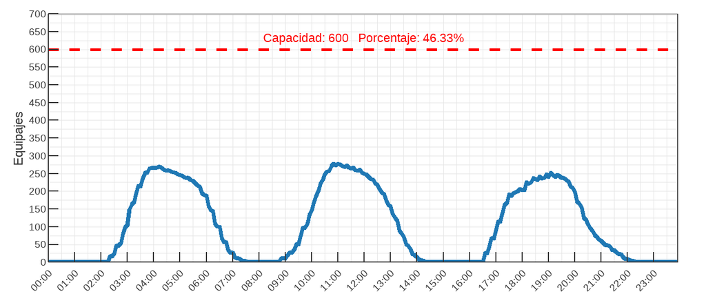

#### Carrusel MC07

##### Línea MU07-1xx

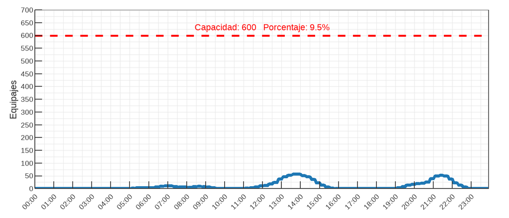

##### Línea MU07-2xx

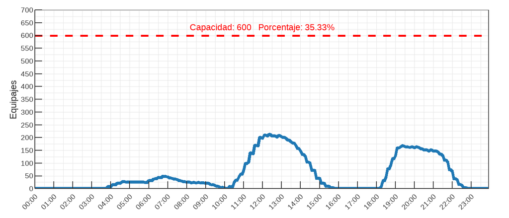

#### Carrusel MC08

##### Línea MU08-1xx

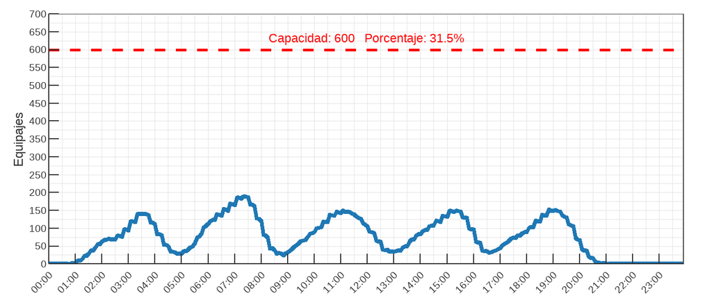

##### Línea MU08-2xx

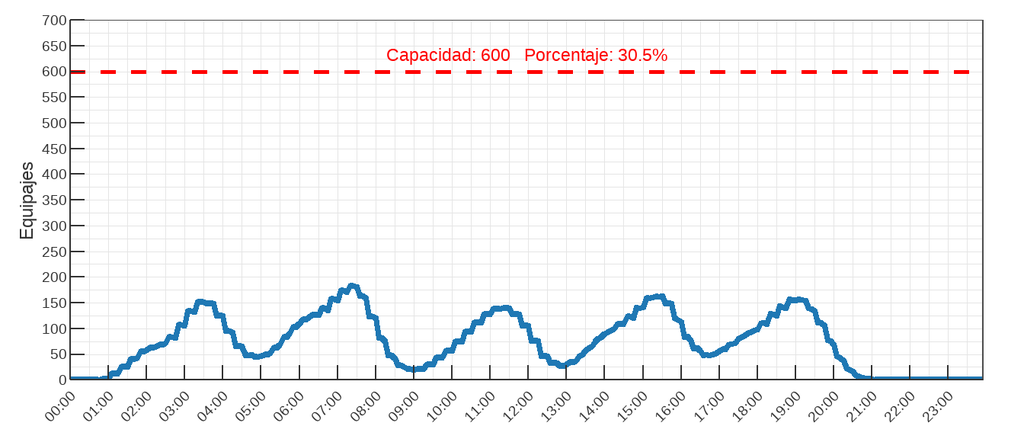

#### Carrusel MC09

##### Línea MU09-1xx

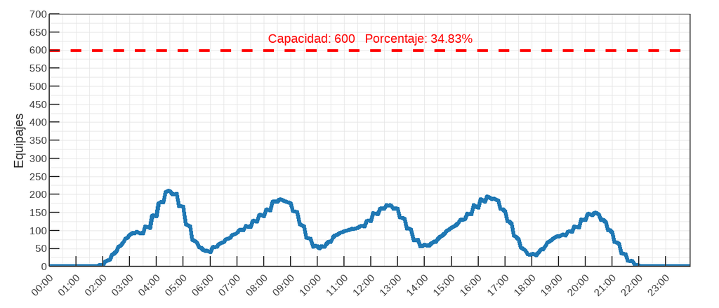

##### Línea MU09-2xx

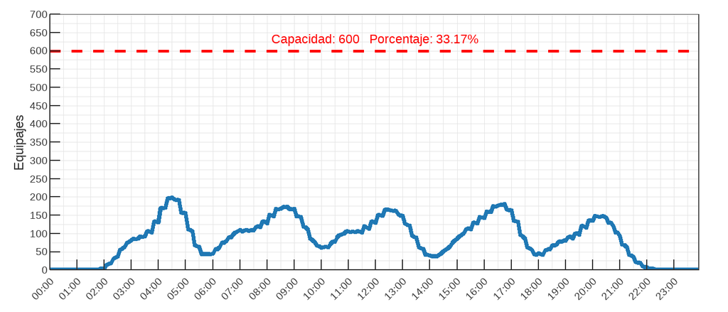

#### Carrusel MC10

##### Línea MU10-1xx

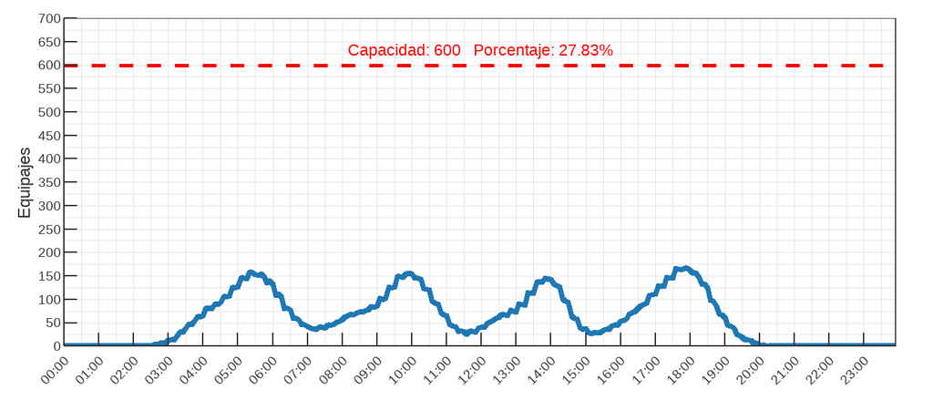

##### Línea MU10-2xx

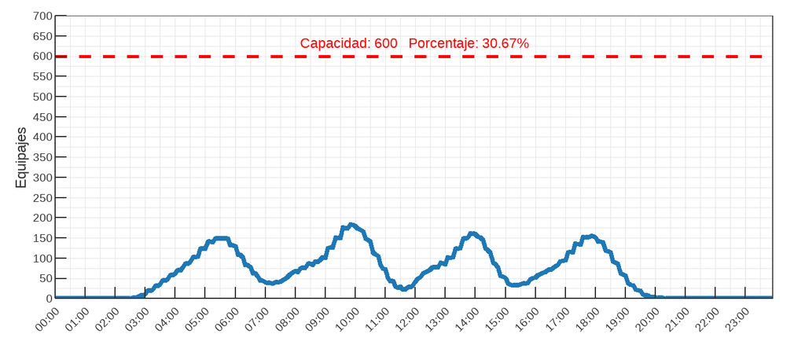

#### Carrusel MC11

##### Línea MU11-1xx

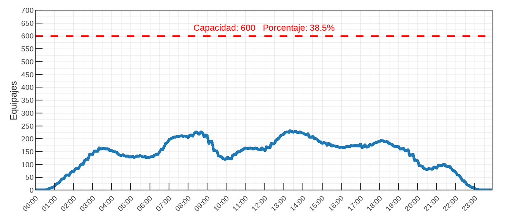

##### Línea MU11-2xx

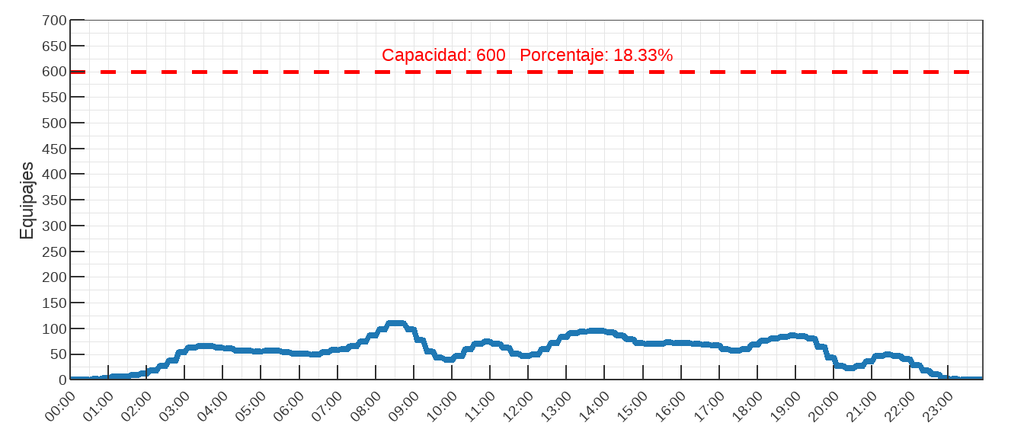

## Early Baggage Storage

### Tabla de Máxima Demanda

En esta tabla se mostrará la máxima demanda en el EBS manual y en el EBS automático.

Tabla de Early Baggage Storage (EBS)

| EBS | Máxima demanda (equipajes/hora) |
| --- | --- |
| Automático | 4 |
| Manual | 46 |

### Resultados Gráficos

A continuación, se muestran las gráficas de demanda en los EBS automático y manual.

#### EBS Automático

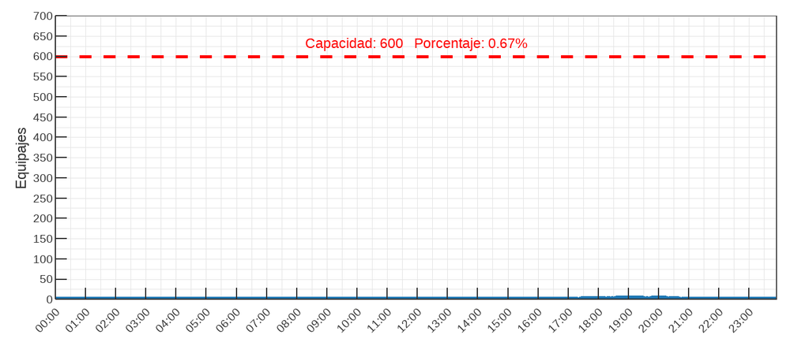

#### EBS Manual

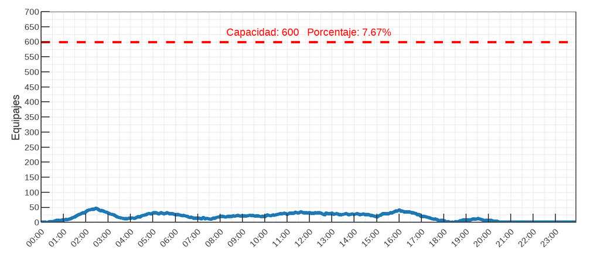